# The Data Cleaning Gauntlet

Possible Answers

Alice M Walsh, R-Ladies Philly

3/28/2020

# Challenge one - Ingest rectangular data

Philadelphia Farmer’s Markets dataset sourced from https://www.opendataphilly.org/dataset/farmers-markets-locations/

This first code chunk loads the data using base R `read.csv()`. You should see new variables appear in your Global Environment.

```r
data_link <- 'http://data.phl.opendata.arcgis.com/datasets/0707c1f31e2446e881d680b0a5ee54bc_0.csv'
markets_base <- read.csv(data_link)
```

```r
# Do you want to load some packages here? Maybe tidyverse?
# Here are the packages I loaded to complete the challenges! You made need more or different ones.

library(stringr)
library(lubridate)
library(tidyverse)
```

## Compare to readr and data.table imports

```r
# Add code here to load the same data (data_link) with readr::read_csv

markets_tidy <- read_csv(data_link) ## UNCOMMENT and FINISH THE CODE
# BONUS: try data.table::fread()

markets_dt <- data.table::fread(data_link) ## UNCOMMENT and FINISH THE CODE
```

# Challenge two - Inspect your data

Questions:

- What is the dimension of the data?

```r
dim(markets_tidy)
```

```
## [1] 50 15
```

- What are the variable/column names?

```r
names(markets_tidy)
```

```
##  [1] "X"                         "Y"
##  [3] "OBJECTID"                  "NEIGHBORHOOD"
##  [5] "NAME"                      "ADDRESS"
##  [7] "ADDRESS_NOTES"             "ZIP"
##  [9] "DAY"                       "TIME"
## [11] "MONTHS"                    "ACCEPT_SNAP_ACCESS"
## [13] "ACCEPT_FMNP"               "ACCEPT_PHILLY_FOOD_BUCKS_"
## [15] "MAJOR_BUS_SUBWAY_ROUTES"
```

- What data type are the variable/columns?

```r
# Three ways
str(markets_tidy)
```

```
## Classes 'spec_tbl_df', 'tbl_df', 'tbl' and 'data.frame': 50 obs. of  15 variables:
##  $ X                        : num  -75.1 -75.1 -75.2 -75.2 -75.2 ...
##  $ Y                        : num  40 40 40 40 40 ...
##  $ OBJECTID                 : num  1 2 3 4 5 6 7 8 9 10 ...
##  $ NEIGHBORHOOD             : chr  "Bridesburg/Kensington/Port Richmond" "Bridesburg/Kensington/Port Richmond" "Center City" "Center City" ...
##  $ NAME                     : chr  "Greensgrow Farm Stand" "Norris Square Neighborhood Project" "Rittenhouse" "Fairmount" ...
##  $ ADDRESS                  : chr  "2501 E. Cumberland Ave" "Diamond St and N. Howard St" "18th and Walnut St" "22nd St. and Fairmount Ave." ...
##  $ ADDRESS_NOTES            : chr  NA NA NA NA ...
##  $ ZIP                      : num  19125 19122 19103 19130 19130 ...
##  $ DAY                      : chr  "Thurs & Sat" "Thurs" "Tues & Sat" "Thurs" ...
##  $ TIME                     : chr  "Thurs: 3-7pm, Sat: 10am-2pm" "1pm - 3pm" "Tues 10am-2pm, Sat 9am-3pm (may to Nov); 10am - 2pm (Dec to Apr)" "3-7pm" ...
##  $ MONTHS                   : chr  "May - September" "May - October" "Tues- June 4th - November 26th; Sat- Year round: 9am - 3pm (May - end of November); 10am - 2pm (December - end of April)" "June 6th- November 27th" ...
##  $ ACCEPT_SNAP_ACCESS       : chr  "Y" "Y" NA "Y" ...
##  $ ACCEPT_FMNP              : chr  "Y" "Y" "Y" "Y" ...
##  $ ACCEPT_PHILLY_FOOD_BUCKS_: chr  "Y" "Y" NA "Y" ...
##  $ MAJOR_BUS_SUBWAY_ROUTES  : chr  "25, 39, 43, 89" "3, 39, 89" "9, 17" "7, 32, 33, 48, PHLASH" ...
##  - attr(*, "spec")=
##   .. cols(
##   ..   X = col_double(),
##   ..   Y = col_double(),
##   ..   OBJECTID = col_double(),
##   ..   NEIGHBORHOOD = col_character(),
##   ..   NAME = col_character(),
##   ..   ADDRESS = col_character(),
##   ..   ADDRESS_NOTES = col_character(),
##   ..   ZIP = col_double(),
##   ..   DAY = col_character(),
##   ..   TIME = col_character(),
##   ..   MONTHS = col_character(),
##   ..   ACCEPT_SNAP_ACCESS = col_character(),
##   ..   ACCEPT_FMNP = col_character(),
##   ..   ACCEPT_PHILLY_FOOD_BUCKS_ = col_character(),
##   ..   MAJOR_BUS_SUBWAY_ROUTES = col_character()
##   .. )
```

```r
summary(markets_tidy)
```

```
##        X                Y            OBJECTID     NEIGHBORHOOD
##  Min.   :-75.25   Min.   :39.92   Min.   : 1.00   Length:50
##  1st Qu.:-75.22   1st Qu.:39.95   1st Qu.:13.25   Class :character
##  Median :-75.17   Median :39.97   Median :25.50   Mode  :character
##  Mean   :-75.17   Mean   :39.98   Mean   :25.50
##  3rd Qu.:-75.15   3rd Qu.:40.02   3rd Qu.:37.75
##  Max.   :-75.02   Max.   :40.10   Max.   :50.00
##      NAME             ADDRESS          ADDRESS_NOTES           ZIP
##  Length:50          Length:50          Length:50          Min.   :19103
##  Class :character   Class :character   Class :character   1st Qu.:19122
##  Mode  :character   Mode  :character   Mode  :character   Median :19130
##                                                           Mean   :19130
##                                                           3rd Qu.:19143
##                                                           Max.   :19151
##      DAY                TIME              MONTHS          ACCEPT_SNAP_ACCESS
##  Length:50          Length:50          Length:50          Length:50
##  Class :character   Class :character   Class :character   Class :character
##  Mode  :character   Mode  :character   Mode  :character   Mode  :character
##
##
##
##  ACCEPT_FMNP        ACCEPT_PHILLY_FOOD_BUCKS_ MAJOR_BUS_SUBWAY_ROUTES
##  Length:50          Length:50                 Length:50
##  Class :character   Class :character          Class :character
##  Mode  :character   Mode  :character          Mode  :character
##
##
##
```

```r
lapply(markets_tidy, class)
```

```
## $X
## [1] "numeric"
##
## $Y
## [1] "numeric"
##
## $OBJECTID
## [1] "numeric"
##
## $NEIGHBORHOOD
## [1] "character"
##
## $NAME
## [1] "character"
##
## $ADDRESS
## [1] "character"
##
## $ADDRESS_NOTES
## [1] "character"
##
## $ZIP
## [1] "numeric"
##
## $DAY
## [1] "character"
##
## $TIME
## [1] "character"
##
## $MONTHS
## [1] "character"
##
## $ACCEPT_SNAP_ACCESS
## [1] "character"
##
## $ACCEPT_FMNP
## [1] "character"
##
## $ACCEPT_PHILLY_FOOD_BUCKS_
## [1] "character"
##
## $MAJOR_BUS_SUBWAY_ROUTES
## [1] "character"
```

```r
# Using dplyr
glimpse(markets_tidy)
```

```
## Observations: 50
## Variables: 15
## $ X                         <dbl> -75.12156, -75.13393, -75.17067, -75.17399,…
## $ Y                         <dbl> 39.97843, 39.98178, 39.95014, 39.96732, 39.…
## $ OBJECTID                  <dbl> 1, 2, 3, 4, 5, 6, 7, 8, 9, 10, 11, 12, 13, …
## $ NEIGHBORHOOD              <chr> "Bridesburg/Kensington/Port Richmond", "Bri…
## $ NAME                      <chr> "Greensgrow Farm Stand", "Norris Square Nei…
## $ ADDRESS                   <chr> "2501 E. Cumberland Ave", "Diamond St and N…
## $ ADDRESS_NOTES             <chr> NA, NA, NA, NA, NA, NA, NA, NA, NA, NA, "In…
## $ ZIP                       <dbl> 19125, 19122, 19103, 19130, 19130, 19107, 1…
## $ DAY                       <chr> "Thurs & Sat", "Thurs", "Tues & Sat", "Thur…
## $ TIME                      <chr> "Thurs: 3-7pm, Sat: 10am-2pm", "1pm - 3pm",…
## $ MONTHS                    <chr> "May - September", "May - October", "Tues- …
## $ ACCEPT_SNAP_ACCESS        <chr> "Y", "Y", NA, "Y", NA, "Y", "Y", "Y", NA, "…
## $ ACCEPT_FMNP               <chr> "Y", "Y", "Y", "Y", NA, "Y", "Y", "Y", NA, …
## $ ACCEPT_PHILLY_FOOD_BUCKS_ <chr> "Y", "Y", NA, "Y", NA, "Y", "Y", "Y", NA, "…
## $ MAJOR_BUS_SUBWAY_ROUTES   <chr> "25, 39, 43, 89", "3, 39, 89", "9, 17", "7,…
```

- How many NA’s are there per variable?

```r
colSums(is.na(markets_tidy))
```

```
##                         X                         Y                  OBJECTID
##                         0                         0                         0
##              NEIGHBORHOOD                      NAME                   ADDRESS
##                         0                         0                         0
##             ADDRESS_NOTES                       ZIP                       DAY
##                        39                         0                         0
##                      TIME                    MONTHS        ACCEPT_SNAP_ACCESS
##                         0                         0                         9
##               ACCEPT_FMNP ACCEPT_PHILLY_FOOD_BUCKS_   MAJOR_BUS_SUBWAY_ROUTES
##                         5                        14                        12
```

```r
lapply(markets_tidy, function(x) sum(is.na(x)))
```

```
## $X
## [1] 0
##
## $Y
## [1] 0
##
## $OBJECTID
## [1] 0
##
## $NEIGHBORHOOD
## [1] 0
##
## $NAME
## [1] 0
##
## $ADDRESS
## [1] 0
##
## $ADDRESS_NOTES
## [1] 39
##
## $ZIP
## [1] 0
##
## $DAY
## [1] 0
##
## $TIME
## [1] 0
##
## $MONTHS
## [1] 0
##
## $ACCEPT_SNAP_ACCESS
## [1] 9
##
## $ACCEPT_FMNP
## [1] 5
##
## $ACCEPT_PHILLY_FOOD_BUCKS_
## [1] 14
##
## $MAJOR_BUS_SUBWAY_ROUTES
## [1] 12
```

```r
# I recommend skimr package!
skimr::skim(markets_tidy)
```

Data summary

| Name | markets_tidy |
| --- | --- |
| Number of rows | 50 |
| Number of columns | 15 |
| _______________________ |  |
| Column type frequency: |  |
| character | 11 |
| numeric | 4 |
| ________________________ |  |
| Group variables | None |

**Variable type: character**

| skim_variable | n_missing | complete_rate | min | max | empty | n_unique | whitespace |
| --- | --- | --- | --- | --- | --- | --- | --- |
| NEIGHBORHOOD | 0 | 1.00 | 4 | 35 | 0 | 14 | 0 |
| NAME | 0 | 1.00 | 8 | 45 | 0 | 50 | 0 |
| ADDRESS | 0 | 1.00 | 13 | 43 | 0 | 50 | 0 |
| ADDRESS_NOTES | 39 | 0.22 | 12 | 36 | 0 | 11 | 0 |
| DAY | 0 | 1.00 | 3 | 22 | 0 | 14 | 0 |
| TIME | 0 | 1.00 | 5 | 64 | 0 | 27 | 0 |
| MONTHS | 0 | 1.00 | 3 | 120 | 0 | 46 | 0 |
| ACCEPT_SNAP_ACCESS | 9 | 0.82 | 1 | 1 | 0 | 1 | 0 |
| ACCEPT_FMNP | 5 | 0.90 | 1 | 1 | 0 | 1 | 0 |
| ACCEPT_PHILLY_FOOD_BUCKS_ | 14 | 0.72 | 1 | 1 | 0 | 1 | 0 |
| MAJOR_BUS_SUBWAY_ROUTES | 12 | 0.76 | 1 | 54 | 0 | 37 | 0 |

**Variable type: numeric**

| skim_variable | n_missing | complete_rate | mean | sd | p0 | p25 | p50 | p75 | p100 | hist |
| --- | --- | --- | --- | --- | --- | --- | --- | --- | --- | --- |
| X | 0 | 1 | -75.17 | 0.04 | -75.25 | -75.22 | -75.17 | -75.15 | -75.02 | ▇▇▇▁▁ |
| Y | 0 | 1 | 39.98 | 0.04 | 39.92 | 39.95 | 39.97 | 40.02 | 40.10 | ▇▇▅▃▂ |
| OBJECTID | 0 | 1 | 25.50 | 14.58 | 1.00 | 13.25 | 25.50 | 37.75 | 50.00 | ▇▇▇▇▇ |
| ZIP | 0 | 1 | 19130.34 | 13.96 | 19103.00 | 19122.00 | 19130.50 | 19143.00 | 19151.00 | ▃▃▇▅▇ |

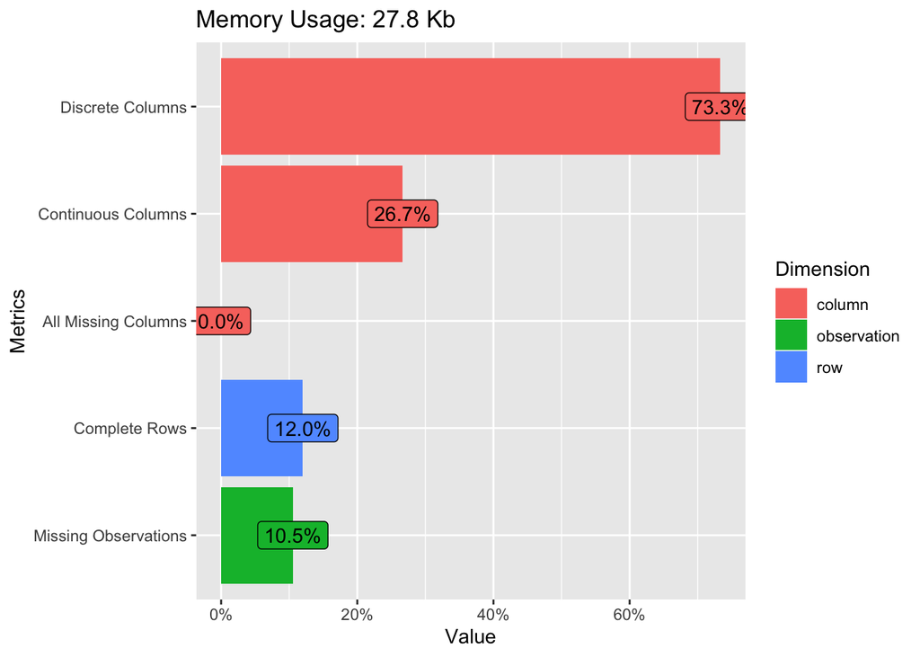

```r
# This is also cool
DataExplorer::plot_intro(markets_tidy)
```

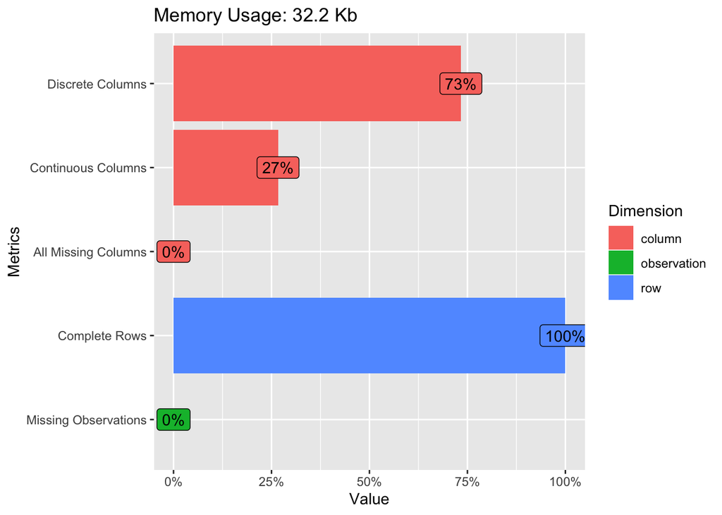

```r
DataExplorer::plot_intro(markets_base)
```

- Is the data “tidy”?
  - No. Each variable does not have its own column and each value does not have its own cell.
- What is different about data imported by read.csv and read_csv??
  - Defaults for read.csv left " “, read_csv converted to”NA"
  - Defaults for read.csv made variables factors, read_csv made character
  - Defaults for read.csv left white space, read_csv trimmed it
  - Column names: read.csv will convert spaces to “.”, read_csv will not
  - Coding of missing values: “na.strings” argument to read.csv
  - Data type doesn’t match: “stringsAsFactors” argument, type.convert() function

## Adjust defaults of read.csv(), read_csv()

```r
# using read.csv
markets_base <- read.csv(data_link,
                         stringsAsFactors = FALSE,
                         strip.white = TRUE,
                         na.strings=c("NA","NaN", " ", ""))
# using read_csv
markets_tidy <- read_csv(data_link,
                         col_types = cols(), # this will suppress col text
                         trim_ws = TRUE, # default is TRUE
                         na = c("NA","NaN", " ", ""))
```

# Challenge three - Fix some dirty fields

## Clean a character column

```r
# Create a new data.frame called markets_clean that copies the dirty data
markets_clean <- markets_tidy

# See what we have
unique(markets_clean$NEIGHBORHOOD)
```

```
##  [1] "Bridesburg/Kensington/Port Richmond" "Center City"
##  [3] "Center city"                         "Germantown/ Chestnut Hill"
##  [5] "Lower North"                         "North"
##  [7] "Northeast"                           "Northwest"
##  [9] "Olney/Oak Lane"                      "Penns Landing"
## [11] "Roxborough/ Manayunk"                "South"
## [13] "Southwest"                           "West"
```

```r
# One way
markets_clean <- markets_clean %>%
  # str_to_title - makes title case
  mutate(NEIGHBORHOOD = stringr::str_to_title(NEIGHBORHOOD))

# Check
unique(markets_clean$NEIGHBORHOOD)
```

```
##  [1] "Bridesburg/Kensington/Port Richmond" "Center City"
##  [3] "Germantown/ Chestnut Hill"           "Lower North"
##  [5] "North"                               "Northeast"
##  [7] "Northwest"                           "Olney/Oak Lane"
##  [9] "Penns Landing"                       "Roxborough/ Manayunk"
## [11] "South"                               "Southwest"
## [13] "West"
```

```r
# or
markets_clean %>% count(NEIGHBORHOOD)
```

```
## # A tibble: 13 x 2
##    NEIGHBORHOOD                            n
##    <chr>                               <int>
##  1 Bridesburg/Kensington/Port Richmond     2
##  2 Center City                             7
##  3 Germantown/ Chestnut Hill               4
##  4 Lower North                             1
##  5 North                                   8
##  6 Northeast                               3
##  7 Northwest                               3
##  8 Olney/Oak Lane                          1
##  9 Penns Landing                           1
## 10 Roxborough/ Manayunk                    2
## 11 South                                   5
## 12 Southwest                               2
## 13 West                                   11
```

```r
# Note: stringr package str_trim() is very useful!
# don't need if done on import with read_csv(data, trim_ws = TRUE)
  # mutate(NEIGHBORHOOD = stringr::str_trim(NEIGHBORHOOD))
```

## Missing values

What to do with missing values (NAs)? tidyr has a useful function, `replace_na()`

```r
# Try out replace_na to replace NAs in ACCEPT_SNAP_ACCESS, ACCEPT_FMNP, ACCEPT_PHILLY_FOOD_BUCKS_ with "N"

markets_clean <- markets_clean %>%
  replace_na(list(ACCEPT_SNAP_ACCESS = "N",
                  ACCEPT_FMNP = "N",
                  ACCEPT_PHILLY_FOOD_BUCKS_ = "N")) %>%
  # I decided to make this logical (True/False)
  mutate_at(vars(starts_with("ACCEPT_")), list(~.=="Y"))

table(markets_clean$ACCEPT_FMNP, exclude = NULL)
```

```
##
## FALSE  TRUE
##     5    45
```

## Create new variables from existing variable

```r
# This is one way...

# Create a factor with the FULL months in order (will be useful later)
# base R has `month.name`,`month.abb`
all_months <- factor(month.name, levels= month.name)
# do same for abvreviations
all_months_abb <- factor(month.abb, levels= month.abb)

# This cleanup with pipes (%>%) does several operations
markets_clean <- markets_clean %>%
  # Manual clean-up
  mutate(MONTHS = sub("TBD|Late |end of |Mid-|mid-|middle of |,","", MONTHS),
         MONTHS = sub("Thanksgiving","November", MONTHS)) %>%
  # Change all to uppercase
  mutate(MONTHS = str_to_title(MONTHS)) %>%
  # Search for any months present in MONTHS (abbreviation finds both full and short)
  mutate(months_abb_vector = list(as.character(all_months_abb)),
         # Convert to numeric representation (1-12)
         months_abb_n = map2(months_abb_vector, MONTHS,
           function(m,y) as.numeric(all_months_abb[str_detect(y, as.character(m))])),
         # Then find min and max
         month_n_min = map_dbl(months_abb_n, function(x) min(x, na.rm = T)),
         month_n_max = map_dbl(months_abb_n, function(x) max(x, na.rm = T))) %>%
  # Special case of year round - make start 1 (Jan), end 12 (Dec)
  mutate(month_n_min = if_else(grepl("Round",MONTHS), 1, month_n_min),
         month_n_max = if_else(grepl("Round",MONTHS), 12, month_n_max)) %>%
  # Replace Inf, -Inf with NA
  mutate_at(vars(starts_with("month_n")), list(~na_if(abs(.), Inf)))
head(select(markets_clean, OBJECTID, month_n_min, month_n_max))
```

```
## # A tibble: 6 x 3
##   OBJECTID month_n_min month_n_max
##      <dbl>       <dbl>       <dbl>
## 1        1           5           9
## 2        2           5          10
## 3        3           1          12
## 4        4           6          11
## 5        5          NA          NA
## 6        6           4          11
```

```r
# The line above ("mutate_at()") is pretty hard to understand,
# here is another way (non-tidyverse) to do it:
  # markets_tidy$month_n_min[is.infinite(markets_tidy$month_n_min)] <- NA
  # markets_tidy$month_n_max[is.infinite(markets_tidy$month_n_max)] <- NA

# Likewise the middle chunk (map2) uses some confusing purrr
# Here is another way to do it:
# Search for any months present in MONTHS
# Convert to numeric representation (1-12)
# Then find min and max

# markets_clean$month_n_min <- sapply(markets_clean$MONTHS,
#       function(m) min(as.numeric(all_months[str_detect(m, as.character(all_months))]),
#                       as.numeric(all_months_abb[str_detect(m, as.character(all_months_abb))])))

# markets_clean$month_n_max <- sapply(markets_clean$MONTHS,
#       function(m) max(as.numeric(all_months[str_detect(m, as.character(all_months))]),
#                     as.numeric(all_months_abb[str_detect(m, as.character(all_months_abb))])))
```

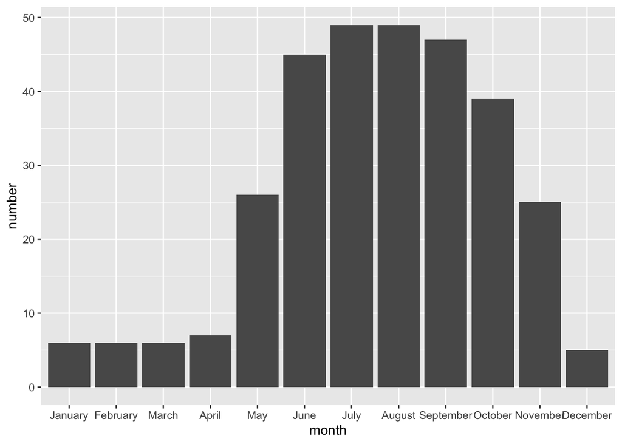

```r
# Create a summarization based on the numeric start and end months
by_month <- data.frame(month = all_months,
                       number = sapply(1:12,
                                function(x)
                                sum(markets_clean$month_n_min <= x & markets_clean$month_n_max >= x,
                                    na.rm = TRUE)))

# Code to plot markets by month
ggplot(by_month, aes(x = month, y = number)) +
  geom_col()
```

```r
# Here is a different way to approach challenge four
# Uses lubridate
markets2 <- markets_tidy
# unique(markets2$MONTHS)

# split by hyphen or dash...
markets2$START_DATE <- str_split_fixed(markets2$MONTHS, "\\p{Pd}", n = 2)[,1]
markets2$END_DATE <- str_split_fixed(markets2$MONTHS, "\\p{Pd}", n = 2)[,2]

# for "year round", start date is January and end date is December
year_round_index <- grepl("year round", markets2$MONTHS, ignore.case = TRUE)
markets2$START_DATE[year_round_index] = "2018-01-01" # year required for lubridate so using 2018, is there a better way?
markets2$END_DATE[year_round_index] = "2018-12-01"

# grep for months within text before first hyphen/dash
# if I had more time could make this a loop through abbreviated months of the year?
# unique(markets2$START_DATE)
january_index <- grepl("January", markets2$START_DATE, ignore.case = TRUE)
markets2$START_DATE[january_index] = "2018-04-01"
april_index <- grepl("April", markets2$START_DATE, ignore.case = TRUE)
markets2$START_DATE[april_index] = "2018-04-01"
may_index <- grepl("May", markets2$START_DATE, ignore.case = TRUE)
markets2$START_DATE[may_index] = "2018-05-01"
june_index <- grepl("June", markets2$START_DATE, ignore.case = TRUE)
markets2$START_DATE[june_index] = "2018-06-01"
july_index <- grepl("July", markets2$START_DATE, ignore.case = TRUE)
markets2$START_DATE[july_index] = "2018-07-01"


# grep for months within text after first hyphen/dash...
# unique(markets2$END_DATE)
aug_index <- grepl("Aug", markets2$END_DATE, ignore.case = TRUE)
markets2$END_DATE[aug_index] = "2018-08-01"
sept_index <- grepl("Sept", markets2$END_DATE, ignore.case = TRUE)
markets2$END_DATE[sept_index] = "2018-09-01"
oct_index <- grepl("Oct", markets2$END_DATE, ignore.case = TRUE)
markets2$END_DATE[oct_index] = "2018-10-01"
nov_index <- grepl("Nov|Thanksgiving", markets2$END_DATE, ignore.case = TRUE)
markets2$END_DATE[nov_index] = "2018-11-01"

# check start and end dates
unique(markets2$START_DATE)
```

```
## [1] "2018-05-01" "2018-01-01" "2018-06-01" "TBD"        "mid"
## [6] "2018-07-01" "Mid"        "2018-04-01"
```

```r
unique(markets2$END_DATE)
```

```
## [1] "2018-09-01" "2018-10-01" "2018-12-01" "2018-11-01" ""
## [6] "2018-08-01"
```

```r
# We have messed up some months...
dplyr::select(markets2, MONTHS, START_DATE, END_DATE) %>% slice(47)
```

```
## # A tibble: 1 x 3
##   MONTHS                                              START_DATE END_DATE
##   <chr>                                               <chr>      <chr>
## 1 Wednesdays: June - August, Saturdays: May – October 2018-06-01 2018-08-01
```

```r
# use lubridate to create variable for date interval the market is open
markets2$INT_OPEN <- interval(markets2$START_DATE, markets2$END_DATE)
```

```r
# Remove any NA in INT_OPEN - just have year round
markets2$INT_OPEN[is.na(markets2$INT_OPEN)] <- interval("2018-01-01", "2018-12-01")
# I was trying to find a way of plotting the interval directly, but didn't find anything

# build data frame with row for each month, first col = month number, second col = num markets open, third col = iso date for first of month (2018)
# sum() is counting the number of rows for which the specified date is within the date interval

markets_open_count <- as.data.frame(
  rbind(
    "01" = c(01, sum(ymd("2018-01-01") %within% markets2$INT_OPEN == TRUE), "2018-01-01"),
    "02" =  c(02, sum(ymd("2018-02-01") %within% markets2$INT_OPEN == TRUE), "2018-02-01"),
    "03" =  c(03, sum(ymd("2018-03-01") %within% markets2$INT_OPEN == TRUE
    ), "2018-03-01"),
    "04" =  c(04, sum(ymd("2018-04-01") %within% markets2$INT_OPEN == TRUE
    ), "2018-04-01"),
    "05" =  c(05, sum(ymd("2018-05-01") %within% markets2$INT_OPEN == TRUE
    ), "2018-05-01"),
    "06" =  c(06, sum(ymd("2018-06-01") %within% markets2$INT_OPEN == TRUE
    ), "2018-06-01"),
    "07" =  c(07, sum(ymd("2018-07-01") %within% markets2$INT_OPEN == TRUE
    ), "2018-07-01"),
    "08" =  c(08, sum(ymd("2018-08-01") %within% markets2$INT_OPEN == TRUE
    ), "2018-08-01"),
    "09" =  c(09, sum(ymd("2018-09-01") %within% markets2$INT_OPEN == TRUE
    ), "2018-09-01"),
    "10" =  c(10, sum(ymd("2018-10-01") %within% markets2$INT_OPEN == TRUE
    ), "2018-10-01"),
    "11" =  c(11, sum(ymd("2018-11-01") %within% markets2$INT_OPEN == TRUE
    ), "2018-11-01"),
    "12" =  c(12, sum(ymd("2018-12-01") %within% markets2$INT_OPEN == TRUE
    ), "2018-12-01")
  )
)

colnames(markets_open_count) <- c("month", "count", "date")
markets_open_count$month <- as.factor(markets_open_count$month)
markets_open_count$count <- as.numeric(as.character(markets_open_count$count))
markets_open_count
```

```
##    month count       date
## 01     1     8 2018-01-01
## 02     2     8 2018-02-01
## 03     3     8 2018-03-01
## 04     4     9 2018-04-01
## 05     5    27 2018-05-01
## 06     6    46 2018-06-01
## 07     7    50 2018-07-01
## 08     8    50 2018-08-01
## 09     9    47 2018-09-01
## 10    10    40 2018-10-01
## 11    11    27 2018-11-01
## 12    12     8 2018-12-01
```

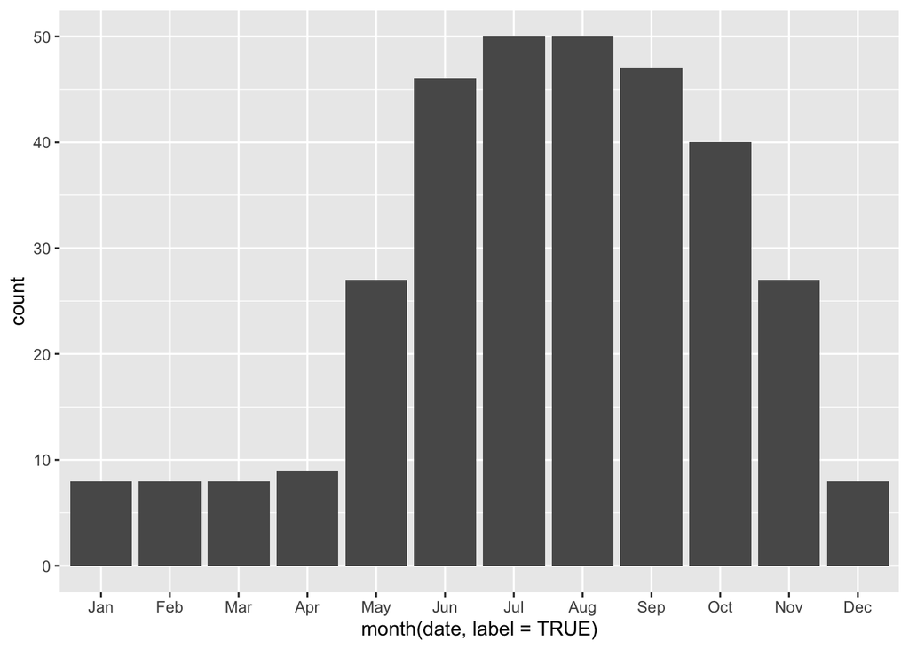

```r
# Code to plot markets by month -

ggplot(markets_open_count, aes(x = month(date, label = TRUE), y = count)) +
  geom_col() +
  scale_x_discrete(limits = month.abb)
```

## Bonus: Try the janitor package

The janitor package has some useful functions!

```r
library(janitor)
```

Here are some demonstrations on the markets data.

```r
markets_clean %>% clean_names() %>% names()
```

```
##  [1] "x"                        "y"
##  [3] "objectid"                 "neighborhood"
##  [5] "name"                     "address"
##  [7] "address_notes"            "zip"
##  [9] "day"                      "time"
## [11] "months"                   "accept_snap_access"
## [13] "accept_fmnp"              "accept_philly_food_bucks"
## [15] "major_bus_subway_routes"  "months_abb_vector"
## [17] "months_abb_n"             "month_n_min"
## [19] "month_n_max"
```

```r
# tabyl is cool
markets_clean %>%
  tabyl(NEIGHBORHOOD, ACCEPT_SNAP_ACCESS) %>%
  adorn_title()
```

```
##                                      ACCEPT_SNAP_ACCESS
##                         NEIGHBORHOOD              FALSE TRUE
##  Bridesburg/Kensington/Port Richmond                  0    2
##                          Center City                  3    4
##            Germantown/ Chestnut Hill                  1    3
##                          Lower North                  1    0
##                                North                  0    8
##                            Northeast                  0    3
##                            Northwest                  1    2
##                       Olney/Oak Lane                  0    1
##                        Penns Landing                  0    1
##                 Roxborough/ Manayunk                  1    1
##                                South                  1    4
##                            Southwest                  0    2
##                                 West                  1   10
```

# Challenge four - pivot the “old way”

```r
zillow_source <- "http://files.zillowstatic.com/research/public/Zip/Zip_MedianListingPrice_AllHomes.csv"
zillow_wide <- read_csv(zillow_source)
dim(zillow_wide)
```

```
## [1] 10874   126
```

The data is 10,000+ rows and 120+ columns. Let’s filter to just keep Philadelphia data:

```r
# This code uses filter from dplyr package - there are other ways you could do this
zillow_wide <- filter(zillow_wide, City == "Philadelphia")
head(zillow_wide[,c(1,2,7:10)])
```

```
## # A tibble: 6 x 6
##   RegionName City         `2010-01` `2010-02` `2010-03` `2010-04`
##   <chr>      <chr>            <dbl>     <dbl>     <dbl>     <dbl>
## 1 19111      Philadelphia    180000    179999    179900   179900
## 2 19124      Philadelphia     89900     89900     90000    89900
## 3 19120      Philadelphia     99900     99900    105000   104950
## 4 19104      Philadelphia        NA        NA        NA       NA
## 5 19148      Philadelphia    165000    169900    169900   169900
## 6 19131      Philadelphia     89750     99450    105000    99950.
```

This data is wide - there are columns for every month with home prices (e.g. “2010-01” and “2016-08”). Instead, we want to have one column with the prices and another with the month and year. How can we convert from wide to long?

This is roughly what I want `zillow_long` to look like:

```r
fake_zillow_long <- tibble(RegionName = c(19143, 19143, 19143, 19143, 19143),
                               City = c("Philadelphia","Philadelphia","Philadelphia","Philadelphia","Philadelphia"),
                               year = c(2010,2010,2010,2010,2010),
                               month = c(1,2,3,4,5),
                               price = c(79450, 77000, 83500, 79450, 79900))

fake_zillow_long
```

```
## # A tibble: 5 x 5
##   RegionName City          year month price
##        <dbl> <chr>        <dbl> <dbl> <dbl>
## 1      19143 Philadelphia  2010     1 79450
## 2      19143 Philadelphia  2010     2 77000
## 3      19143 Philadelphia  2010     3 83500
## 4      19143 Philadelphia  2010     4 79450
## 5      19143 Philadelphia  2010     5 79900
```

```r
# Create a new data frame, zillow_long, that contains reshaped data
# Try using the tidyr function, gather()
# ?gather

# One solution (nice b/c dont need to know all col names)
zillow_long <- gather(zillow_wide,
                      key = "year-month", #bad col name!
                      value = "price",
                      starts_with("20")) %>%
  separate(`year-month`,
           into = c("year","month"))

# Basically the same but specify column range instead of starts_with
# also dont autofill NA
zillow_long <- gather(zillow_wide,
                      key = "year-month", #bad col name!
                      value = "price",
                      `2010-01`:`2019-12`,
                      na.rm = TRUE) %>%
  separate(`year-month`,
           into = c("year","month"),
           convert = TRUE) #if you want new year and month cols to be numeric

head(zillow_long)
```

```
## # A tibble: 6 x 9
##   RegionName City    State Metro        CountyName   SizeRank  year month  price
##   <chr>      <chr>   <chr> <chr>        <chr>           <dbl> <int> <int>  <dbl>
## 1 19111      Philad… PA    Philadelphi… Philadelphi…      239  2010     1 180000
## 2 19124      Philad… PA    Philadelphi… Philadelphi…      327  2010     1  89900
## 3 19120      Philad… PA    Philadelphi… Philadelphi…      413  2010     1  99900
## 4 19148      Philad… PA    Philadelphi… Philadelphi…      559  2010     1 165000
## 5 19131      Philad… PA    Philadelphi… Philadelphi…      607  2010     1  89750
## 6 19145      Philad… PA    Philadelphi… Philadelphi…      763  2010     1 129450
```

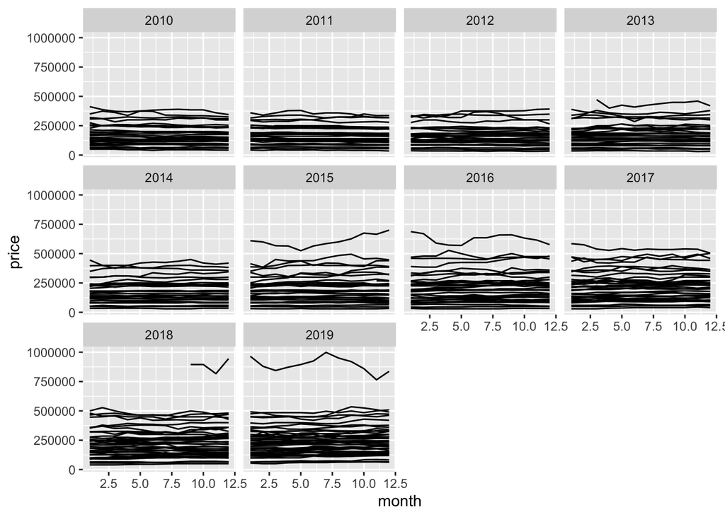

```r
# Now we can plot the prices over time for each Philadelphia RegionName (zip code)
# Here is some example code you can modify to fit your dataset or change to make prettier

ggplot(zillow_long, aes(x = month, y = price, group = RegionName)) +
  geom_line() +
  facet_wrap(~year)
```

# Challenge five - pivot the “new way”

```r
# Create a new data frame, zillow_long, that contains reshaped data
# ?pivot_longer

# One way
zillow_long <- pivot_longer(zillow_wide,
                      cols = starts_with("20"),
                      names_to = "year-month",
                      values_to = "price") %>%
  separate(`year-month`,
           into = c("year","month"))

# With some other options
zillow_long <- pivot_longer(zillow_wide,
                      cols = starts_with("20"),
                      names_to = "year-month",
                      values_to = "price",
                      values_drop_na = TRUE) %>%
  separate(`year-month`,
           into = c("year","month"))

head(zillow_long)
```

```
## # A tibble: 6 x 9
##   RegionName City    State Metro        CountyName   SizeRank year  month  price
##   <chr>      <chr>   <chr> <chr>        <chr>           <dbl> <chr> <chr>  <dbl>
## 1 19111      Philad… PA    Philadelphi… Philadelphi…      239 2010  01    180000
## 2 19111      Philad… PA    Philadelphi… Philadelphi…      239 2010  02    179999
## 3 19111      Philad… PA    Philadelphi… Philadelphi…      239 2010  03    179900
## 4 19111      Philad… PA    Philadelphi… Philadelphi…      239 2010  04    179900
## 5 19111      Philad… PA    Philadelphi… Philadelphi…      239 2010  05    179900
## 6 19111      Philad… PA    Philadelphi… Philadelphi…      239 2010  06    179900
```

```r
# Create a new data frame, zillow_long, that contains reshaped data
# ?pivot_wider

# Modify below
zillow_wide_2 <- pivot_wider(zillow_long,
                      names_from = "month",
                      values_from = "price",
                      names_prefix = "price_")

head(zillow_wide_2)
```

```
## # A tibble: 6 x 19
##   RegionName City  State Metro CountyName SizeRank year  price_01 price_02
##   <chr>      <chr> <chr> <chr> <chr>         <dbl> <chr>    <dbl>    <dbl>
## 1 19111      Phil… PA    Phil… Philadelp…      239 2010    180000   179999
## 2 19111      Phil… PA    Phil… Philadelp…      239 2011    171400   169450
## 3 19111      Phil… PA    Phil… Philadelp…      239 2012    164900   165000
## 4 19111      Phil… PA    Phil… Philadelp…      239 2013    154000   154900
## 5 19111      Phil… PA    Phil… Philadelp…      239 2014    153900   154900
## 6 19111      Phil… PA    Phil… Philadelp…      239 2015    159450   159900
## # … with 10 more variables: price_03 <dbl>, price_04 <dbl>, price_05 <dbl>,
## #   price_06 <dbl>, price_07 <dbl>, price_08 <dbl>, price_09 <dbl>,
## #   price_10 <dbl>, price_11 <dbl>, price_12 <dbl>
```

# Challenge six - ingest JSON and make a data.frame

```r
library(jsonlite)
wawa_json <- jsonlite::fromJSON(here::here('exercises','wawa.json'))
class(wawa_json)
```

```
## [1] "list"
```

```r
dplyr::glimpse(wawa_json$locations)
```

```
## Observations: 50
## Variables: 17
## $ locationID       <chr> "08154", "08113", "00086", "08069", "08112", "08093"…
## $ storeName        <chr> "WAWA, STORE # 8154", "WAWA, STORE # 8113", "WAWA, S…
## $ openType         <chr> "18hours", "24hours", "24hours", "18hours", "24hours…
## $ areaManager      <chr> "CHRISTENSEN, RONALD", "CHRISTENSEN, RONALD", "HORN,…
## $ regionalDirector <chr> "ALTEMUS, REBECCA", "ALTEMUS, REBECCA", "ALTEMUS, RE…
## $ telephone        <chr> "(267) 866-7609", "215) 315-3683", "215-977-9558", "…
## $ isActive         <lgl> FALSE, FALSE, FALSE, FALSE, FALSE, FALSE, FALSE, FAL…
## $ storeOpen        <chr> "06:00:00", "00:00:00", "00:00:00", "05:00:00", "00:…
## $ storeClose       <chr> "22:00:00", "00:00:00", "00:00:00", "23:00:00", "00:…
## $ open24Hours      <lgl> FALSE, TRUE, TRUE, FALSE, TRUE, TRUE, TRUE, TRUE, FA…
## $ storeNumber      <chr> "08154", "08113", "00086", "08069", "08112", "08093"…
## $ lastUpdated      <chr> "02/17/2020 5:05 AM", "02/17/2020 5:05 AM", "02/17/2…
## $ amenities        <df[,6]> <data.frame[26 x 6]>
## $ addresses        <list> [<data.frame[2 x 6]>, <data.frame[2 x 6]>, <data.fr…
## $ fuelTypes        <list> [<data.frame[0 x 0]>, <data.frame[0 x 0]>, <data.fr…
## $ hasMenu          <lgl> TRUE, TRUE, TRUE, TRUE, TRUE, TRUE, TRUE, TRUE, TRUE…
## $ addressUrl       <chr> "pa-philadelphia-33-s-16th-st", "pa-philadelphia-130…
```

```r
# One way
flat_wawa <- wawa_json$locations

# amenitites can get added with simple jsonlite::flatten()
# dim(flat_wawa$amenities)
flat_wawa <- flatten(flat_wawa)

# addresses has two rows x 6 cols per row, can use tidyr::unnest()
# dim(flat_wawa$addresses[[1]])
flat_wawa <- unnest(flat_wawa, cols = addresses)

# fuelTypes has data frame for locations with gas
#   description price currency
# 1    Unleaded 2.419      USD
# 2        Plus 2.739      USD
# 3     Premium 2.879      USD
# 4      Diesel 2.999      USD
# 5       Super 2.919      USD

flat_wawa <- unnest(flat_wawa, cols = fuelTypes, keep_empty = TRUE)

dim(flat_wawa)
```

```
## [1] 220  29
```

```r
# Note: could unnest again for loc
```

## Extra challenges

That wawa data is still probably not in a good shape to analyze.  
How would we make it tidy?  
*Can at least remove columns like “currency” and “hasMenu” that have no variation*

Is it better to keep it nested? *In this case, it may be better to work with the data nested or separate into multiple data frames.*

```r
# At least fix the addresses where context="friendly", "physical"
flat_wawa <- flat_wawa %>%
  pivot_wider(names_from = context, values_from = address:loc) %>%
  # remove empty columns
  janitor::remove_empty("cols")

dim(flat_wawa)
```

```
## [1] 110  29
```